# Memo - Examining SO2 time series data

2/3/2021

## Objectives

In the analyses to date, the result for SO2 is a bit unclaer. We see an increase with exposure to both upwind and downwind wells within 1 km. In this memo, I examine the raw observations, exposure metrics, and residuals.

## Analysis

| monitor_id | carb_basin | county | is_urban |
| --- | --- | --- | --- |
| 060831013 | South Central Coast | Santa Barbara | 0 |

Data for exposed monitor-days (within 1 km of a preproduction well, where we see the effect) with SO2 observations comes from just one monitor in Santa Barbara (though there are more monitors exposed to production volume).

#### Plot. Exposure by year

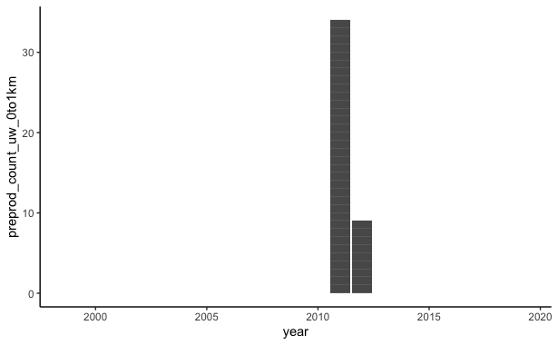

Exposure at the monitor is confined to 2011-12.

#### Plot. Correlation between upwind and downwind exposure

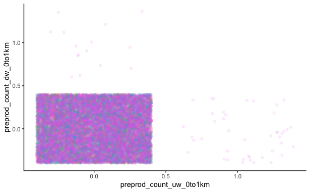

No apparent correlation between exposure to upwind and downwind wells (these are likely the same wells)

#### Plot. Residuals x upwind exposure, exposed monitors only

Residuals from adjust linear regression model with meteorological and day-of-week controls with FE for basin-month and basin-year.

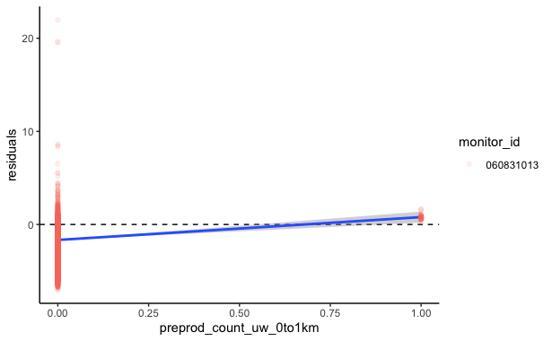

This is our primary positive result for SO2

#### Plot. Residuals x downwind placebo “exposure,” exposed monitor only

Residuals from adjust linear regression model with meteorological and day-of-week controls with FE for basin-month and basin-year.

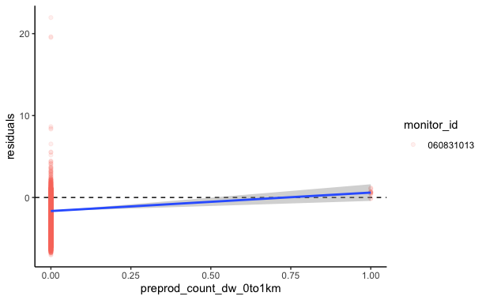

A positive result, similar to the result for upwind wells

#### Plot. Residuals x upwind exposure, all monitors

```
There were 12 warnings (use warnings() to see them)
```

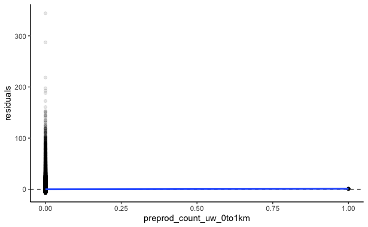

#### Plot. Time series of SO2 at monitor 060831013 (Samta Barbara County)

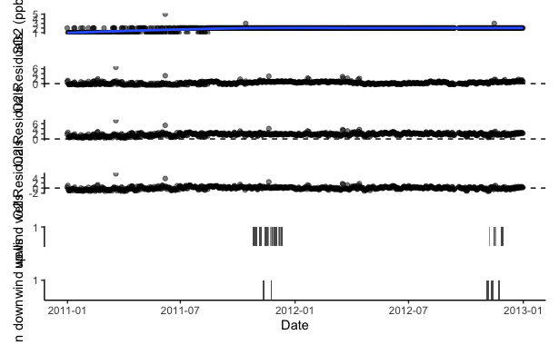

We have time series data for 1999-2019; for this figure, we focus on 2011-12. Puzzlingly, the SO2 measurements seem to only be 1 or 2 (with a few outliers). This is a red flag. I get the sense that there may be an error in the SO2 data; if these are the correct data, then I don’t think we can make a case for any association for SO2